# Лабораторная работа №2

## Создание учётных записей пользователей

Вводим команду *sudo cat /etc/shadow | grep caro*, чтобы увидеть запись о пароле пользователя carol в файле /etc/shadow (рис. 32)

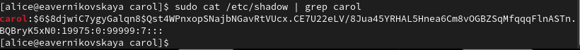

ИНформация о пароле пользователя carol

## Создание учётных записей пользователей

Пояснение: в этой строке

1. Имя пользователя
2. Зашифрованный пароль — это поле содержит пароль пользователя.
3. Количество дней с 1 января 1970 года, когда пароль был изменён в последний раз
4. Количество дней до того, как пароль может быть изменён. Это поле позволяет системным администраторам использовать более строгую политику паролей, когда невозможно сразу вернуться к исходному паролю при его изменении. Обычно это поле устанавливается в значение 0
5. Количество дней, после которых необходимо изменить пароль. Это поле содержит максимальный срок действия пароля. По умолчанию установлено 99999 (около 273 лет)

## Создание учётных записей пользователей

6. За сколько дней до истечения срока действия пароля пользователь получает предупреждение. Это поле используется для предупреждения пользователя о сроке, когда происходит принудительное изменение пароля. По умолчанию установлено значение 7
7. Через сколько дней после истечения срока действия пароля учётная запись будет отключена. После истечения срока действия пароля пользователи больше не смогут входить в систему
8. Количество дней с 1 января 1970 года, когда эта учётная запись была отключена. Администратор может установить это поле для отключения учёной записи. Обычно это лучший подход, чем удаление учёной записи, так как все связанные с ней свойства и файлы учётной записи будут сохранены
9. Зарезервированное поле, которое добавлено для будущего использования

## Создание учётных записей пользователей

Изменяем свойства пароля пользователя carol следующим образом *sudo passwd -n 30 -w 3 -x 90 carol* (рис. 33)

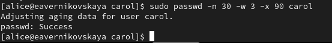

Изменение свойств пользователя carol

## Создание учётных записей пользователей

Проверяем изменения в строке с данными о пароле пользователя carol в файле /etc/shadow (рис. 34)

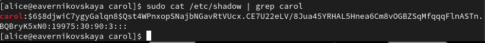

Измененная информация о пароле пользователя carol

## Создание учётных записей пользователей

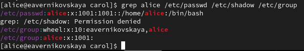

alice в файлах

## Создание учётных записей пользователей

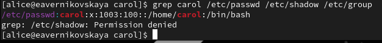

carol в файлах

## Работа с группами

Заходим в учётную запись пользователя alice и создаём группы main и third, введя *sudo groupadd main* и *sudo groupadd third* (рис. 37)

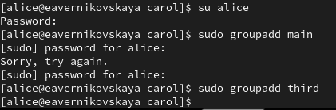

Создание групп main и third

## Работа с группами

Создаём пользователей dan, dave и david. Также задаём им пароли (рис. 38)

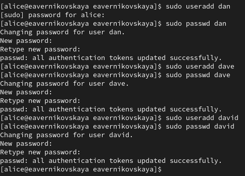

Создание пользователей dan, dave и david

## Работа с группами

Используем usermod для добавления пользователей alice и bob в группу main, а carol, dan, dave и david — в группу third (рис. 39)

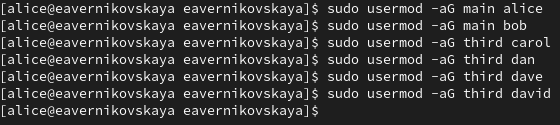

## Работа с группами

Командой *id carol* проверяем что пользователь carol правильно добавлен в группу third. Пользователю carol должна быть назначена основная группа с идентификатором gid = 100 (users) (рис. 40)

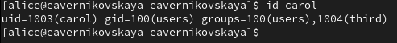

Проверка пользователя carol

## Работа с группами

Определяем, участниками каких групп являются другие созданные вами пользователи (alice и bob входят в группу main. dan, dave,david в группу third) (рис. 41)

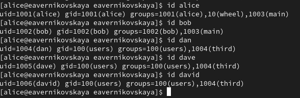

Информация о группах других пользователей

# Подведение итогов

## Выводы

В ходе выполнения лабораторной работы мы получили представление о работе с учётными записями пользователей и группами пользователей в операционной системе типа Linux.

## Список литературы

1. Лаборатораня работа №1 [Электронный ресурс] URL: https://esystem.rudn.ru/pluginfile.php/2400677/mod_resource/content/4/003-user_management.pdf